# IODS course project

Next we scale the data set in order to make it possible to analyse it using clustering analysis. When the data is scaled, the mean of every variable is 0. Then we divide the data to train and test sets.

```r
#Standardize the dataset
boston_scaled <- as.data.frame(scale(Boston))

#Summaries of the scaled variables
summary(boston_scaled)
```

```
##       crim                 zn               indus              chas
##  Min.   :-0.419367   Min.   :-0.48724   Min.   :-1.5563   Min.   :-0.2723
##  1st Qu.:-0.410563   1st Qu.:-0.48724   1st Qu.:-0.8668   1st Qu.:-0.2723
##  Median :-0.390280   Median :-0.48724   Median :-0.2109   Median :-0.2723
##  Mean   : 0.000000   Mean   : 0.00000   Mean   : 0.0000   Mean   : 0.0000
##  3rd Qu.: 0.007389   3rd Qu.: 0.04872   3rd Qu.: 1.0150   3rd Qu.:-0.2723
##  Max.   : 9.924110   Max.   : 3.80047   Max.   : 2.4202   Max.   : 3.6648
##       nox                rm               age               dis
##  Min.   :-1.4644   Min.   :-3.8764   Min.   :-2.3331   Min.   :-1.2658
##  1st Qu.:-0.9121   1st Qu.:-0.5681   1st Qu.:-0.8366   1st Qu.:-0.8049
##  Median :-0.1441   Median :-0.1084   Median : 0.3171   Median :-0.2790
##  Mean   : 0.0000   Mean   : 0.0000   Mean   : 0.0000   Mean   : 0.0000
##  3rd Qu.: 0.5981   3rd Qu.: 0.4823   3rd Qu.: 0.9059   3rd Qu.: 0.6617
##  Max.   : 2.7296   Max.   : 3.5515   Max.   : 1.1164   Max.   : 3.9566
##       rad               tax             ptratio            black
##  Min.   :-0.9819   Min.   :-1.3127   Min.   :-2.7047   Min.   :-3.9033
##  1st Qu.:-0.6373   1st Qu.:-0.7668   1st Qu.:-0.4876   1st Qu.: 0.2049
##  Median :-0.5225   Median :-0.4642   Median : 0.2746   Median : 0.3808
##  Mean   : 0.0000   Mean   : 0.0000   Mean   : 0.0000   Mean   : 0.0000
##  3rd Qu.: 1.6596   3rd Qu.: 1.5294   3rd Qu.: 0.8058   3rd Qu.: 0.4332
##  Max.   : 1.6596   Max.   : 1.7964   Max.   : 1.6372   Max.   : 0.4406
##      lstat              medv
##  Min.   :-1.5296   Min.   :-1.9063
##  1st Qu.:-0.7986   1st Qu.:-0.5989
##  Median :-0.1811   Median :-0.1449
##  Mean   : 0.0000   Mean   : 0.0000
##  3rd Qu.: 0.6024   3rd Qu.: 0.2683
##  Max.   : 3.5453   Max.   : 2.9865
```

```r
#Create a categorical variable of the crime rate
crime <- cut(boston_scaled$crim, breaks = quantile(boston_scaled$crim), include.lowest = TRUE, label = c("low", "med_low", "med_high", "high" ))

# add the new categorical value to scaled data
boston_scaled <- dplyr::select(boston_scaled, -crim)
boston_scaled <- data.frame(boston_scaled, crime)

#Divide the dataset to train and test sets, so that 80% of the data belongs to the train set
ind <- sample(nrow(boston_scaled),  size = nrow(boston_scaled) * 0.8)
train <- boston_scaled[ind,]
test <- boston_scaled[-ind,]
```

Next we will fit the linear discriminant analysis on the train set using the categorical crime rate as the target variable and all the other variables in the data set as predictor variables

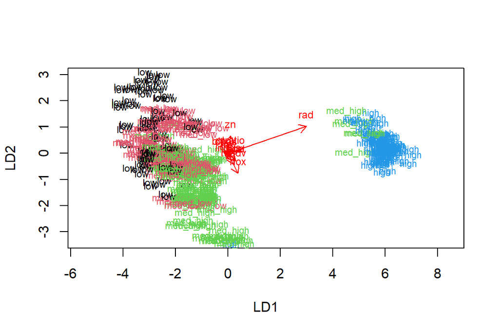

```r
lda.fit <- lda(crime ~ ., data = train)

# the function for lda biplot arrows
lda.arrows <- function(x, myscale = 1, arrow_heads = 0.1, color = "red", tex = 0.75, choices = c(1,2)){
  heads <- coef(x)
  arrows(x0 = 0, y0 = 0,
         x1 = myscale * heads[,choices[1]],
         y1 = myscale * heads[,choices[2]], col=color, length = arrow_heads)
  text(myscale * heads[,choices], labels = row.names(heads),
       cex = tex, col=color, pos=3)
}
classes <- as.numeric(train$crime)

#Draw the LDA (bi)plot
plot(lda.fit, dimen = 2, col = classes, pch = classes)
lda.arrows(lda.fit, myscale = 1)
```

Now we will predict the classes with the LDA model on the test data and examine the results.

```r
#Save the crime categories from the test set and then remove the categorical crime variable from the test dataset.
correct_classes <- test$crime
test <- dplyr::select(test, -crime)

#Predict classes with test data
lda.pred <- predict(lda.fit, newdata = test)

#Cross tabulate the results
table(correct = correct_classes, predicted = lda.pred$class)
```

```
##           predicted
## correct    low med_low med_high high
##   low       21       6        0    0
##   med_low    6      16        4    0
##   med_high   1      11       13    0
##   high       0       0        0   24
```

Finally, we will perform k-means clustering

```r
#Reload and standardize the Boston dataset
data("Boston")
boston_scaled <- as.data.frame(scale(Boston))

#Make the euclidean distance matrix
dist_eu <- dist(boston_scaled)

#Summary of the distances
summary(dist_eu)
```

```
##    Min. 1st Qu.  Median    Mean 3rd Qu.    Max.
##  0.1343  3.4625  4.8241  4.9111  6.1863 14.3970
```

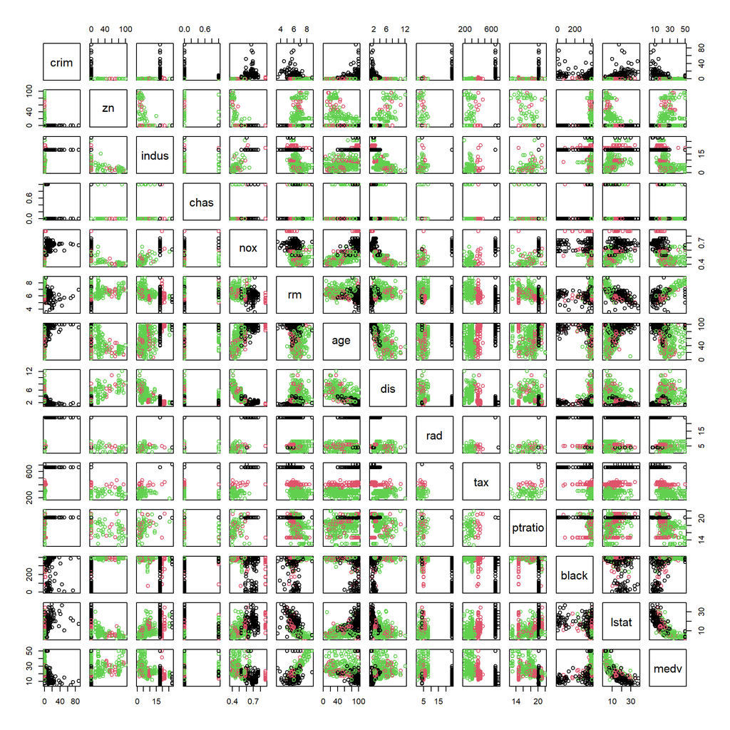

```r
#Run k-means algorithm on the dataset using 3 clusters
km <- kmeans(Boston, centers = 3)

#Plot the Boston dataset with clusters
pairs(Boston, col = km$cluster)
```

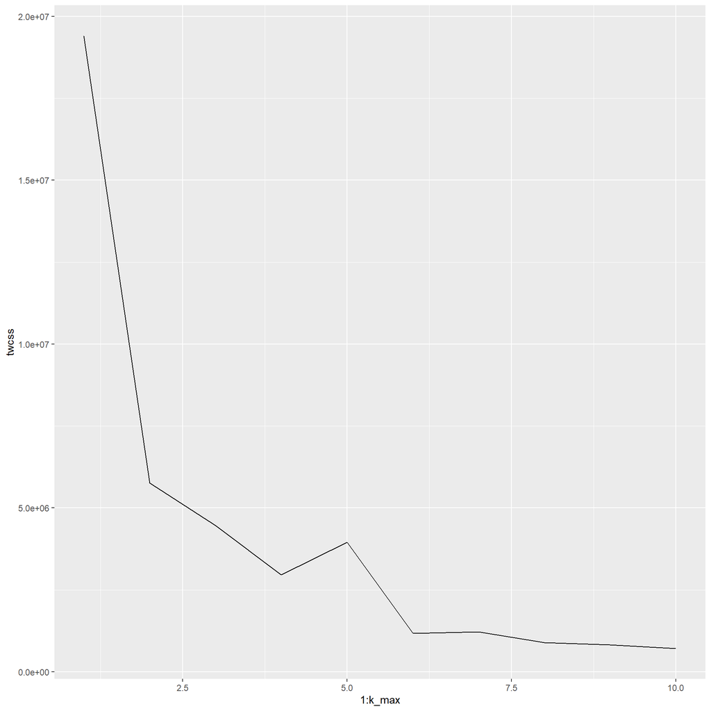

```r
#Investigate what is the optimal number of clusters (1-10)
k_max <- 10

#Calculate the total within sum of squares and visualize the results
twcss <- sapply(1:k_max, function(k){kmeans(Boston, k)$tot.withinss})
qplot(x = 1:k_max, y = twcss, geom = 'line')
```

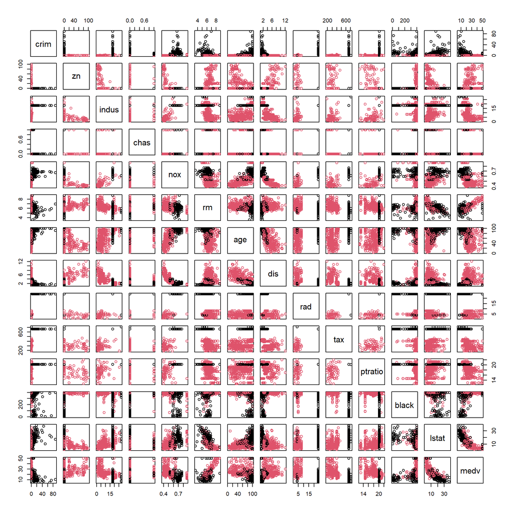

```r
#Redo the clustering with the optimal number of clusters (2) and plot the results
km <- kmeans(Boston, centers = 2)
pairs(Boston, col = km$cluster)
```

By plotting the number of clusters vs. WCSS we can see that the greatest drop happens when the number of clusters is 2, so that seems to be the optimal number of clusters.

From the pair plot we can see that the variables which seem to most affect the clustering are zn, indus, rad and tax.